# Machine Learning - Random Forests

Python programming

Machine learning

Random forests

This lesson introduces machine learning with random forests using a synthetic spatial transcriptomics dataset of the human cortex. You will learn how to prepare features and labels, split data into training and test sets, train a `RandomForestClassifier` in `scikit-learn` and interpret model outputs. Along the way, you will visualize spatial patterns of cortical layers and marker genes, inspect an individual decision tree and evaluate model performance using accuracy and confusion matrices.

Authors

Noor Sohail

Will Gammerdinger

Published

March 14, 2026

Keywords

Spatial transcriptomics, Decision trees, Model evaluation

Approximate time: 50 minutes

## Learning objectives

In this lesson, we will:

- Load a spatial transcriptomics dataset of the human cortex
- Train a random forest classifier to predict cortical layer labels based on spatial location and gene expression
- Evaluate the performance of the random forest classifier

## Overview of lesson

Maching learning and AI are becoming increasingly important tools in the world and the life sciences are no exception. These tools are able to learn patterns from data without the need for a human to define the rules. This makes them powerful for making predictions and uncovering insights from complex datasets.

In this lesson, we will be using a machine learning algorithm called a **random forest classifier** to predict the cortical layer labels of cells in a spatial transcriptomics dataset. This is a great example of how machine learning can be used to make predictions and uncover insights from biological datasets. We will be using the `scikit-learn` library in Python to train our random forest classifier and evaluate its performance.

## Machine learning

Machine learning is a subfield of artificial intelligence that focuses on training models to learn patterns from data and make predictions without a human explicitly programming the rules. There are many different types of machine learning algorithms, but they all share the same general steps of:

1. Preparing the training and test datasets
2. Training the model on the training data
3. Evaluating the model’s performance on the test data
4. Using the model to make predictions on new data

These algorithms can be used for a wide range of applications, including image recognition, natural language processing and predictive modeling.

### Random forest classifiers

Random forests allow you to predict a categorical variable (cortical layer) based on one or more predictor variables (spatial coordinates and gene expression scores). To do so, the algorithm builds multiple decision trees, which are models that make predictions based on a series of binary decisions (`True` or `False`).

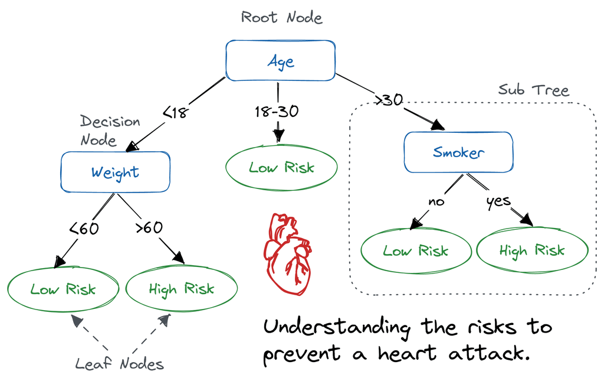

Figure 1: Example of a decision tree where the variables are age, weight and smoker to predict risk level of a heart attack.  
*Image source: [DataCamp](https://www.datacamp.com/tutorial/decision-tree-classification-python)*

These decision trees are made up of decision nodes, which are the points where the data is split based on a predictor variable, and leaf nodes, which are the final predictions made by the tree.

The random forest algorithm generates multiple of these decision trees based upon the training data. Each tree is built upon a random subset of the data and variables. This randomness helps to reduce overfitting and improve the generalizability of the model. Therefore, each tree will learn different patterns from the data.

Once the model has been trained, we can supply a new dataset and run it through the model. In this case, the data will run through each of the decision trees in the random forest and make a prediction. Then, a majority vote is taken across the decision of all the trees to make the final prediction.

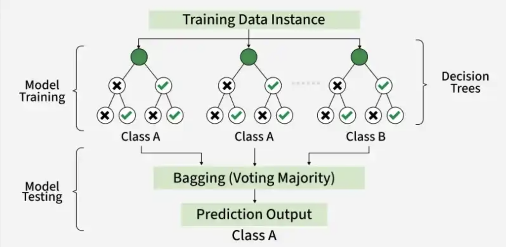

Figure 2: Example of a random forest with 3 decision trees to generate a prediction based upon majority voting.  
*Image source: [GeeksforGeeks](https://www.geeksforgeeks.org/random-forest-classifier-using-scikit-learn/)*

## Cortical layer dataset

To provide a real-world example of how to use machine learning in research, we will be using a synthetic [Visium HD](https://www.10xgenomics.com/platforms/visium/product-family) spatial transcriptomics dataset. In this type of experiment, you take a piece of tissue and lay it on a grid. Then, each spot on the grid is genomically sequenced such that you know **both the spatial location and gene expression** of each spot.

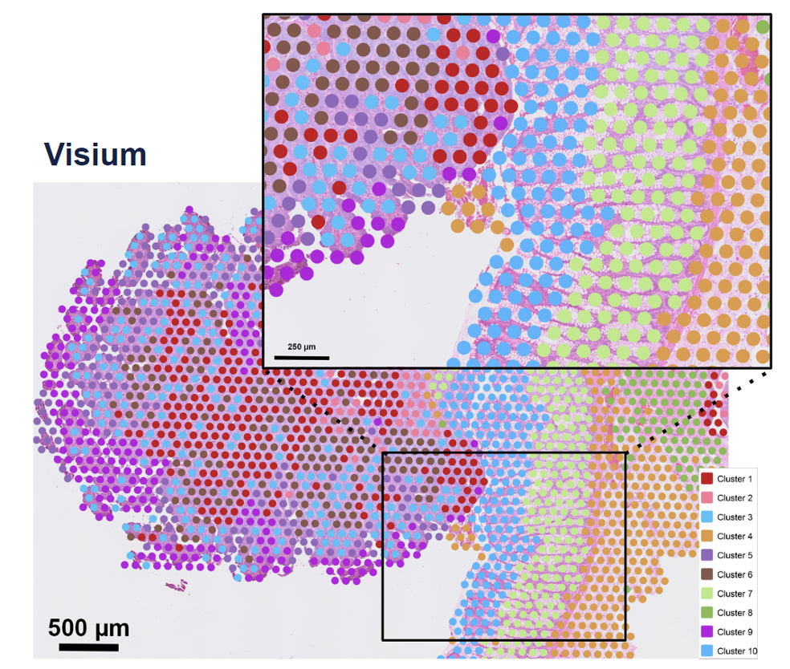

Figure 3: Example of a Visium spatial transcriptomics dataset, where each spot has two key pieces of information: spatial location and gene expression.  
*Image source: [10x Genomics](https://www.10xgenomics.com/blog/your-introduction-to-visium-hd-spatial-biology-in-high-definition)*

The human cortex is a great use case for this technology because the brain is divvied into layers 1-6 and a white matter layer. A good analogy would be to think of them as an onion, where the layers are stacked right on top of each other spatially (x, y coordinates).

The layers are relatively distinct in their spatial locations but also have genes that are expressed highly in one layer and not the others. This makes it a great use case for machine learning because we can use both the spatial location and gene expression to predict which layer a spot belongs to.

**We will be using a synthetic cortical dataset with labelled cortical layers to train a random forest classifier to predict which layer a cell belongs to.**

### Cortical information

```python
# Load libraries
import pandas as pd
import seaborn as sns
import matplotlib.pyplot as plt

from sklearn.ensemble import RandomForestClassifier
from sklearn.model_selection import train_test_split
from sklearn.metrics import accuracy_score, confusion_matrix

# Load synthetic cortical dataset
df_cortical = pd.read_csv("data/synthetic_cortex_data.csv")

# Inspect the loaded dataset
df_cortical.head()
```

Table 1: Cortical cells data, where the x and y coordinates represent the spatial locations of each cell as well as the cortical layer they belong to.

|  | cell_barcode | x | y | depth | cortical_layer | AQP4 | HPCAL1 | FREM3 | TRABD2A | KRT17 | MOBP |
| --- | --- | --- | --- | --- | --- | --- | --- | --- | --- | --- | --- |
| 0 | cell_000000 | 0.000000 | 0.0 | 0.000000 | L1 | 2.709412 | 0.637789 | 0.686888 | 0.000000 | 0.014255 | 0.571001 |
| 1 | cell_000001 | 0.006289 | 0.0 | 0.012579 | L1 | 4.404602 | 1.485036 | 0.000000 | 0.000000 | 0.060433 | 0.355317 |
| 2 | cell_000002 | 0.012579 | 0.0 | 0.025157 | L2 | 5.746630 | 2.453983 | 0.348598 | 0.178012 | 0.046239 | 0.487520 |
| 3 | cell_000003 | 0.018868 | 0.0 | 0.037736 | L1 | 2.503209 | 3.946293 | 1.179006 | 0.000000 | 0.070852 | 0.290224 |
| 4 | cell_000004 | 0.025157 | 0.0 | 0.050314 | L1 | 0.459022 | 0.000000 | 0.812647 | 0.000000 | 0.000000 | 0.917574 |

As this is a spatial dataset, we can visualize where on the tissue each spot is located by plotting the x and y coordinates of each spot and coloring the points by the cortical layer that they belong to:

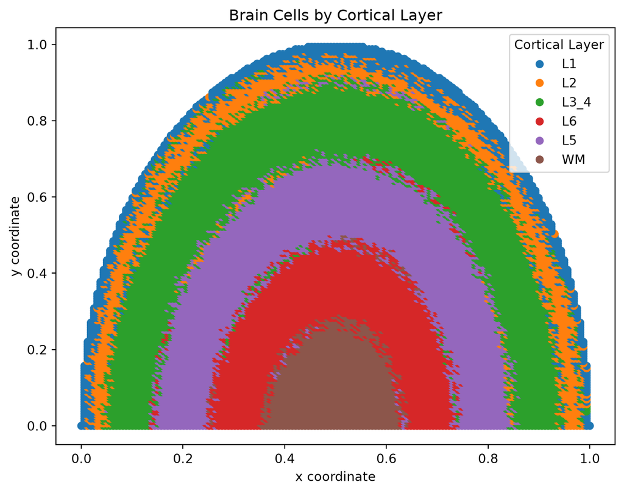

Figure 5: Spatial plot of the cortical spots colored by the cortical layer they belong to.

```python
# Initialize a plot with a specific size
plt.figure(figsize = (8, 6))

# Plot the spatial locations of the spots colored by the cortical layer they belong to
sns.scatterplot(data=df_cortical,
                x="x", y="y",
                hue="cortical_layer",
                edgecolor=None,
                palette="tab10")

# Add a plot title
plt.title("Brain Cells by Cortical Layer")

# Add an x-axis label
plt.xlabel("x coordinate")

# Add a y-axis label
plt.ylabel("y coordinate")

# Add a title to the legend
plt.legend(title="Cortical Layer")

# Render the plot
plt.show()
```

So now we have a better idea of what the cross-section of the cortex looks like and where the different layers are located.

However, just using the x and y coordinates of each spot is not enough. You may have noticed that there appears to be some mixing of layers near the boundaries. Luckily for us, the different cortical layers have known genes that are uniquely expressed in the layers. We can take a quick look at some of these marker genes that are used to identify the different cortical layers in the original paper that this dataset is based on:

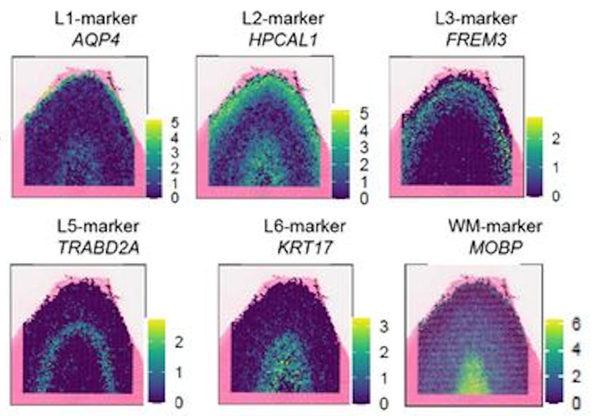

Figure 6: Example of the spatial expression of known marker genes for each cortical layer.  
*Image source: [Rai et al. (2026)](https://www.biorxiv.org/content/10.64898/2026.01.12.698703v1.full)*

In the dataset, you have have noted that we also have columns: `AQP4`, `HPCAL1`, `FREM3`, `TRABD2A`, `KRT17` and `MOBP`. These are the [log-normalized expression](https://hbctraining.github.io/Intro-to-scRNAseq/lessons/07_SCT_normalization.html#normalization) values for those genes in each spot. Similar to the figure from above, we can visualize the expression of a marker gene in each spot (scatterplot point) across the cortex to see the pattern of values across the different layers. This will give us a better idea of how we can use both the spatial location and gene expression to predict which layer a spot belongs to.

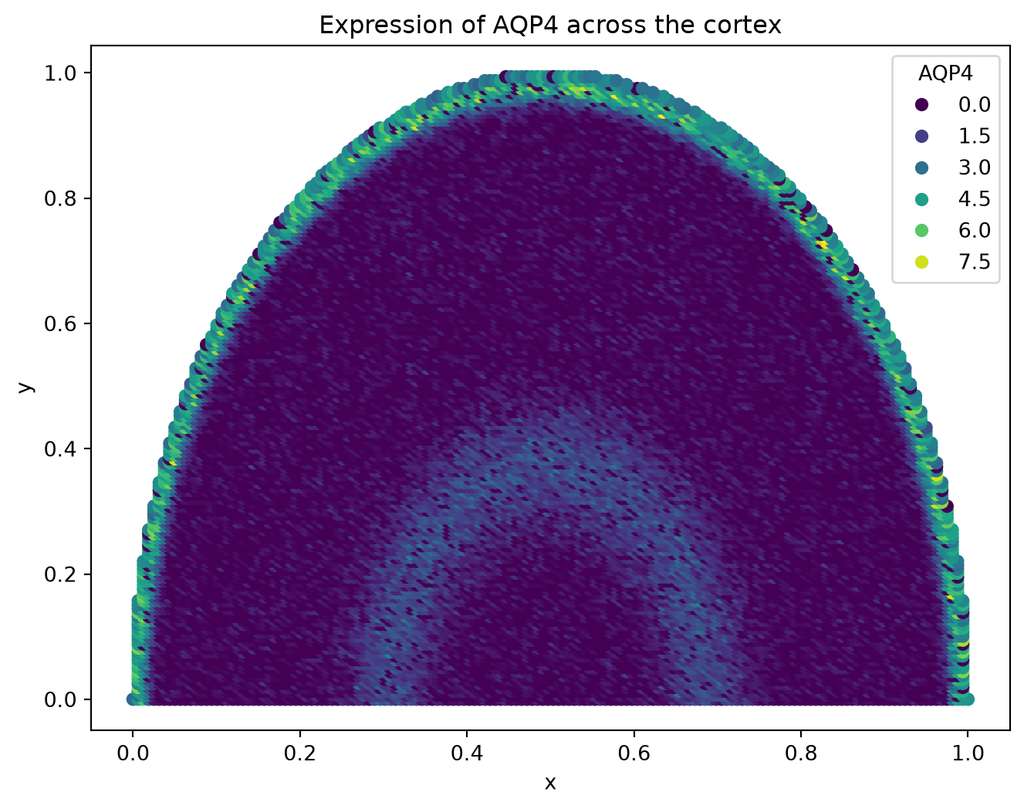

Figure 7: Spatial plot of the gene expression of the Layer 1 marker gene, AQP4, across the cortex.

```python
# Initialize a plot with a specific size
plt.figure(figsize = (8, 6))

# Plot the spatial expression of AQP4 across the cortex
sns.scatterplot(data = df_cortical,
                x = "x",
                y = "y",
                hue = "AQP4",
                palette = "viridis",
                edgecolor = None
)

# Add a plot title
plt.title("Expression of AQP4 across the cortex")

# Render the plot
plt.show()
```

**NoteMaking multiple subplots in a loop**

Alternatively, we could have plotted all six genes together by doing something like:

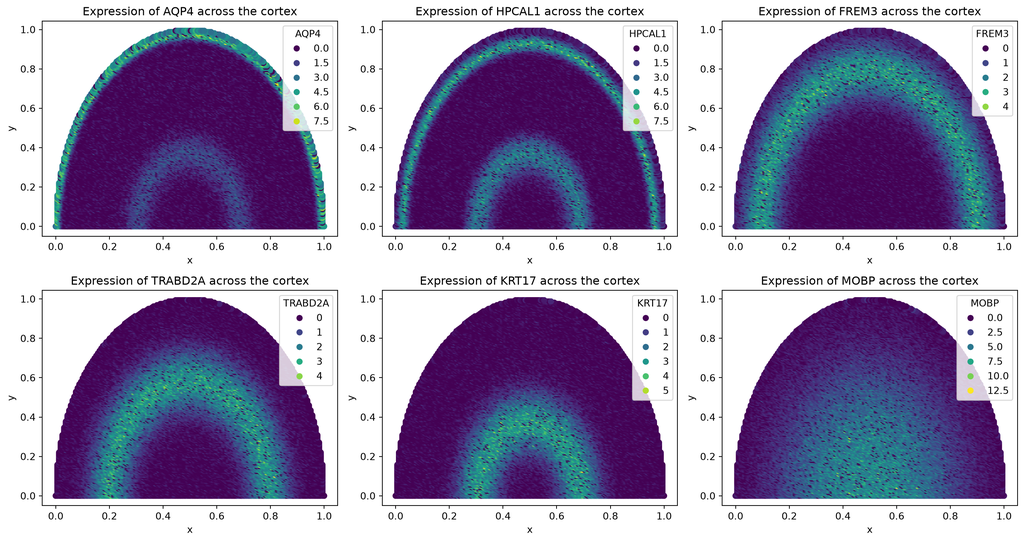

Figure 8: Spatial plot of the gene expression of known marker genes for each cortical layer.

```python
# List of marker genes to plot
genes = ["AQP4", "HPCAL1", "FREM3",
         "TRABD2A", "KRT17", "MOBP"]

# Initialize a plot with rows and columns for each gene
fig, axes = plt.subplots(2, 3, figsize=(15, 8))

# Make axes a flat list so we can index easily
axes = axes.flatten()

# Loop through each gene creating a plot
for i, gene in enumerate(genes):
    ax = axes[i]
    sns.scatterplot(
        data=df_cortical,
        x="x", y="y",
        hue=gene,
        palette="viridis",
        edgecolor=None,
        ax=ax
    )
    ax.set_title(f"Expression of {gene} across the cortex")

# Adjust spacing so that figures fit neatly together
plt.tight_layout()

# Render the plot
plt.show()
```

In the above code, we first initialized a plot with 2 rows and 3 columns - with the goal of plotting each of the 6 genes in our dataset. This creates an **2D array of plots** which we can then access to generate each of our plots.

We could have proceeded using the `[row, column]` indexing we have been using for matrices, but that is more complex as we would need to keep track of both rows and columns in the for loop. Instead, we can use the `flatten()` method to convert this **2D array of plots into a list of plots**, which is easier to index in the `for` loop.

You will also note that in our `for` loop there is a comma `i, gene`. This is because `enumerate(genes)` will provide the index (`i`) in addition to the gene name (`gene`) as it is looping through `genes`. Because it is returning two variables, we need to assign them to two variables and we use the comma to separate the two variables we are wanting to return values to.

**We will be using this synthetic dataset to train a random forest classifier to predict the cortical layer labels based on the spatial location and gene expression of each cell.**

## Training a random forest classifier

Now that we have a basic understanding of how random forests work, let’s dive into training one with our cortical dataset. We will be using the `RandomForestClassifier` class from the `sklearn.ensemble` module to train our model.

### Preparing training dataset

The *learning* of machine learning comes from the fact that these algorithms must first learn patterns. This is accomplished by taking a subset of labelled data, the **training set**, to train the model. From this, the random forest classifier would learn how to predict the cortical layer of a cell based on its coordinates and gene expression. Additionally, we also need a **test set** to evaluate the performance of the model. The test set is a subset of the data that the model has not seen during training (but has labels), and it is used to assess the accuracy of the model.

First, we are going to define what is the target label we want to predict (`cortical_layer`), and what are the predictor variables we want to use to make that prediction, (`x` coordinates, `y` coordinates and gene expression). Oftentimes, the predictor features and target label will be referred to as the `X` and `y`, respectively.

```python
# Define the predictor feature columns
feature_cols = ["x", "y", "AQP4", "HPCAL1", "FREM3",
                "TRABD2A", "KRT17", "MOBP"]

# Define the target label column
target_col = "cortical_layer"

# Set X for future use in training and prediction
X = df_cortical[feature_cols]

# Set y for future use in training and prediction
y = df_cortical[target_col]
```

With this information, we can now prepare our training and test dataset with `train_test_split()` from the `sklearn.model_selection` module. This function will split our dataset into a **training set and a test set**.

We will train the model on the training set and then evaluate its performance (accuracy) on the test set. We supply the following parameters into the function:

- `test_size`: proportion of the dataset that we want to use as the test set (30% of the data for testing and 70% for training).
- `stratify`: ensure that the distribution of the target label (`cortical_layer`) is the same in both the training and test sets. This is to reduce bias due to sampling and ensure that the model is trained on a representative sample of the data.
- `random_state`: random seed for reproducibility.

```python
# Split the dataset into the training and test dataset and also split the predictor variables and target labels
X_train, X_test, y_train, y_test = train_test_split(
    X,
    y,
    test_size = 0.3,
    random_state = 42,
    stratify = y
)
```

**NoteAssigning output to multiple object**

`train_test_split` will return four objects (`X_train`, `X_test`, `y_train`, `y_test`), which is why each object is separated by a comma in the assignment. The objects contain: - `X_train` - The predictor variables, `x` coordinates, `y` coordinates along with our gene expression, for our training set - `X_test` - The predictor variables, `x` coordinates, `y` coordinates along with our gene expression, for our testing set - `y_train`: The target labels for our training set - `y_test`: The target labels for our testing set

### Train random forest classifier

To create the model, first we are going to initialize an instance of the `RandomForestClassifier` class from the `sklearn.ensemble` module. We will specify the number of trees in the forest using the `n_estimators` parameter and set a random seed, `random_state`, for reproducibility.

```python
# Initialize the random forest classifier
rf = RandomForestClassifier(n_estimators = 100,
                            random_state = 42,
                            class_weight = "balanced")
```

Next, we will train the model using the `fit()` method, which takes in the predictor variables (spatial coordinates and gene expression) and the target variable (cortical layer) from the training data.

```python
# Train the random forest classifier model
rf.fit(X_train, y_train)
```

```
RandomForestClassifier(class_weight='balanced', random_state=42)
```

Now that we have trained a model, we can visualize how **one** of the decision trees in the random forest is making its predictions. This can help us understand how the model is learning to predict the cortical layer labels based on the spatial location and gene expression of each cell. Here, we see the first few splits in the decision tree:

[figure not shown]

Visualization of a single decision tree from the random forest model (truncated to depth `max_depth`).

## Predict cortical layer labels

With this model, `rf`, we can now predict the cortical layer labels of the test dataset using the `predict()` method. Once again, we are supplying the predictor variables, but this time for the **test data** instead of the training data. The model will use the patterns it learned from the training data to predict which cortical layer each spot belongs to.

```python
# Predict cortical layers for test dataset
y_pred = rf.predict(X_test)
```

So now we have `y_pred`, but what is this output?

```python
# Inspect the data type of y_pred
type(y_pred)
```

```
numpy.ndarray
```

It is a NumPy array! So we can access the first few elements to see what the predicted labels look like:

```python
# View the first few predicted labels
y_pred[0:5]
```

```
array(['WM', 'L6', 'L6', 'L5', 'L5'], dtype=object)
```

So we see that the output of the `predict()` method is an array of predicted cortical layer labels for each spot in the test dataset.

## Assessing model performance

At this point, we have the predicted labels for the test dataset, but how do we know if these predictions are accurate? To evaluate the performance of our model, we can compare the predicted labels to the true labels of the test dataset.

### Accuracy of model predictions

Now that we have the predicted and true labels of the test dataset, we can calculate the accuracy of our model’s predictions. Accuracy is calculated as the number of correct predictions divided by the total number of predictions.

```python
# Calculate the accuracy of the model's predictions
acc = accuracy_score(y_test, y_pred)

# Convert proportion to percentage
accuracy_percentage = acc * 100

# Print out the accuracy
print(accuracy_percentage)
```

```
85.17898962863833
```

Our accuracy is quite high! This tells us that our model is doing a good job at predicting the cortical layer labels based on the x, y coordinates and gene expression. However, accuracy alone does not always give us the full picture of how well our model is performing.

### Confusion matrices

If your accuracy is low, you can look at the confusion matrix to see which classes are being misclassified and potentially adjust your model or data accordingly. Confusion matrices are a common way to evaluate which labels are being correctly predicted and which are being incorrectly predicted. This can help you understand where your model is making mistakes and how to improve it.

```python
# Obtain the data labels
class_names = sorted(y.unique())

# Create a confusion matrix of true and predicted labels
cm = confusion_matrix(y_true = y_test,
                      y_pred = y_pred,
                      labels = class_names)

# Print out the confusion matrix
print(cm)
```

```
[[ 286  111    9    0    0    0]
 [ 112  508   67   17    0    0]
 [  30  132 1611  105   10    0]
 [   0   20   67 1401   62    7]
 [   1    1   17   41  861   30]
 [   0    0    0    6   41  425]]
```

The easiest way to interpret this confusion matrix is to visualize it as a heatmap, where the intensity of the color represents the number of predictions for each class. This can help you quickly identify which classes are being misclassified and which are being correctly classified.

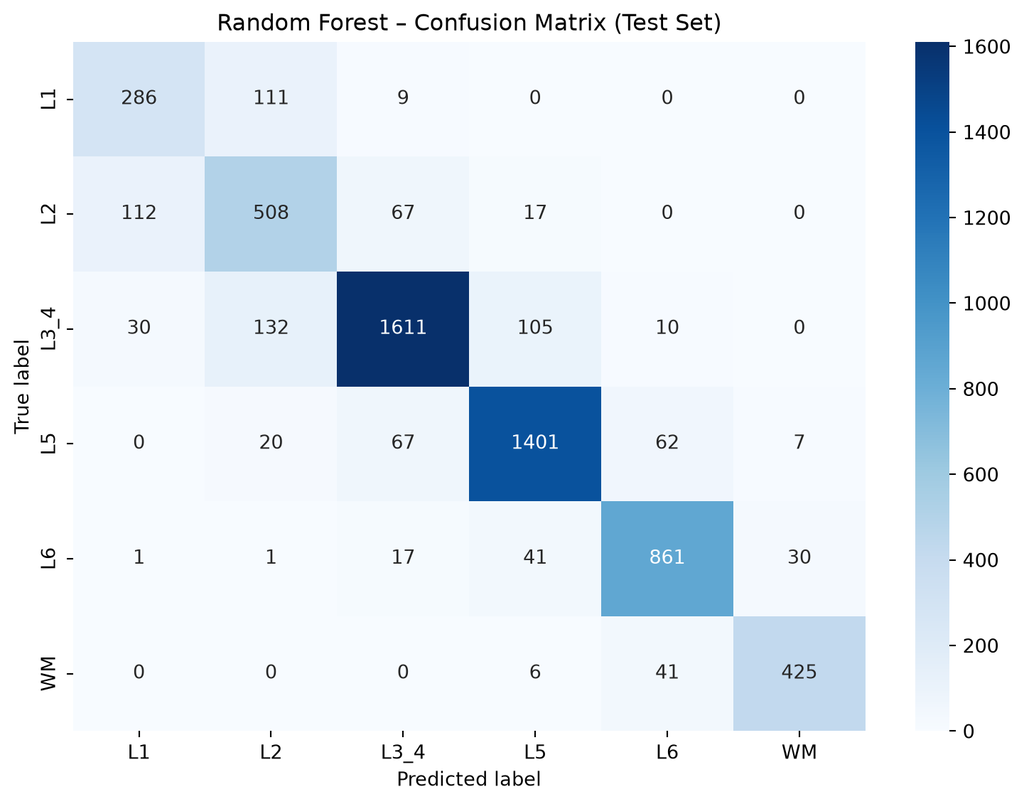

Figure 9: Confusion matrix to evaluate the performance of the random forest classifier on the test dataset for each cortical layer.

```python
# Initialize a plot with a specific size
plt.figure(figsize = (8, 6))

# Create a heatmap from the confusion matrix
sns.heatmap(
    data = cm,
    annot = True,
    fmt = "g",
    cmap = "Blues",
    xticklabels = class_names,
    yticklabels = class_names
)

# Add a plot title
plt.title("Random Forest – Confusion Matrix (Test Set)")

# Add an x-axis label
plt.xlabel("Predicted label")

# Add an y-axis label
plt.ylabel("True label")

#
plt.tight_layout()

# Render the plot
plt.show()
```

Our accuracy is quite high, so the diagonal (correct predictions) has the highest values. However, we can see that there are several instances of misclassification (the 15% inaccurate predictions). It makes sense that we see the **most error in the prediction when layers are adjacent to one another**. This is because the boundary between when one layer starts and another ends is not always clear, and there may be some mixing of layers near the boundaries.

## Next steps

With this model, you could try to predict the cortical layer labels of other unlabelled datasets. You could also try to use different predictor variables (e.g., only gene expression or only spatial coordinates) to see how that affects the accuracy of the model’s predictions.

Back to Schedule